# STAT6620 Homework 3, Part 1

(Naive Bayes Spam Detector)

Abe-Jones, Yumiko (ua8242)

April 13, 2016

```r
# Loading all the libraries
library(tm)
```

```r
library(e1071)
library(gmodels)
library(SnowballC)
library(wordcloud)
```

### Part I: Get the Data

As we know, the data are provided to us from the textbook website, so let’s load’er up.

```r
# read the sms data into the sms data frame
sms_raw <- read.csv("sms_spam.csv", stringsAsFactors = FALSE)
```

### Part II: Explore and Prep the Data

#### Part IIA: Exploration

```r
# examine the structure of the sms data
str(sms_raw)
```

```
## 'data.frame':    5559 obs. of  2 variables:
##  $ type: chr  "ham" "ham" "ham" "spam" ...
##  $ text: chr  "Hope you are having a good week. Just checking in" "K..give back my thanks." "Am also doing in cbe only. But have to pay." "complimentary 4 STAR Ibiza Holiday or £10,000 cash needs your URGENT collection. 09066364349 NOW from Landline not to lose out!"| __truncated__ ...
```

```r
# convert spam/ham to factor.
sms_raw$type <- factor(sms_raw$type)

# examine the type variable more carefully
str(sms_raw$type)
```

```
##  Factor w/ 2 levels "ham","spam": 1 1 1 2 2 1 1 1 2 1 ...
```

```r
table(sms_raw$type)
```

```
##
##  ham spam
## 4812  747
```

…so the data are arranged in two variables: (1) the label (e.g. identifying whether the message is ham or spam, with “1” indicating “ham” and “2” indicating “spam”) and (2) the actual content of the message. It appears that there are 4,812 legitimate (“ham”) messages and 747 spam messages in this file.

#### Part IIB: Data cleaning

We move onto creating a “bag of words” (corpus) to be used in our text mining analysis, and cleaning it up:

```r
# build a corpus using the text mining (tm) package
sms_corpus <- VCorpus(VectorSource(sms_raw$text))

# examine the sms corpus
print(sms_corpus)
```

```
## <<VCorpus>>
## Metadata:  corpus specific: 0, document level (indexed): 0
## Content:  documents: 5559
```

```r
inspect(sms_corpus[1])
```

```
## <<VCorpus>>
## Metadata:  corpus specific: 0, document level (indexed): 0
## Content:  documents: 1
##
## [[1]]
## <<PlainTextDocument>>
## Metadata:  7
## Content:  chars: 49
```

```r
as.character(sms_corpus[[1]])
```

```
## [1] "Hope you are having a good week. Just checking in"
```

Now we move on to cleaning up the corpus:

```r
# clean up the corpus using tm_map()
sms_corpus_clean <- tm_map(sms_corpus, content_transformer(tolower)) # convert to lower case
sms_corpus_clean <- tm_map(sms_corpus_clean, removeNumbers) # remove numbers
sms_corpus_clean <- tm_map(sms_corpus_clean, removeWords, stopwords()) # remove stop words
sms_corpus_clean <- tm_map(sms_corpus_clean, removePunctuation) # remove punctuation

# more cleaning using SnowballC package.
sms_corpus_clean <- tm_map(sms_corpus_clean, stemDocument) # strip words down to their stems
sms_corpus_clean <- tm_map(sms_corpus_clean, stripWhitespace) # eliminate unneeded whitespace

# create a document term sparse matrix
sms_dtm <- DocumentTermMatrix(sms_corpus_clean)
```

#### Part IIC: Create training and test datasets

The final part of data preparation is to partition the data into training and test datasets to get ready for the modeling.

```r
# creating training and test datasets
sms_dtm_train <- sms_dtm[1:4169, ]
sms_dtm_test  <- sms_dtm[4170:5559, ]

# also save the labels
sms_train_labels <- sms_raw[1:4169, ]$type
sms_test_labels  <- sms_raw[4170:5559, ]$type

# check that the proportion of spam is similar
prop.table(table(sms_train_labels))
```

```
## sms_train_labels
##       ham      spam
## 0.8647158 0.1352842
```

```r
prop.table(table(sms_test_labels))
```

```
## sms_test_labels
##       ham      spam
## 0.8683453 0.1316547
```

Now we use word cloud visualization to get a feel for the overall difference in the kinds of words that are in the ham group vs the spam group:

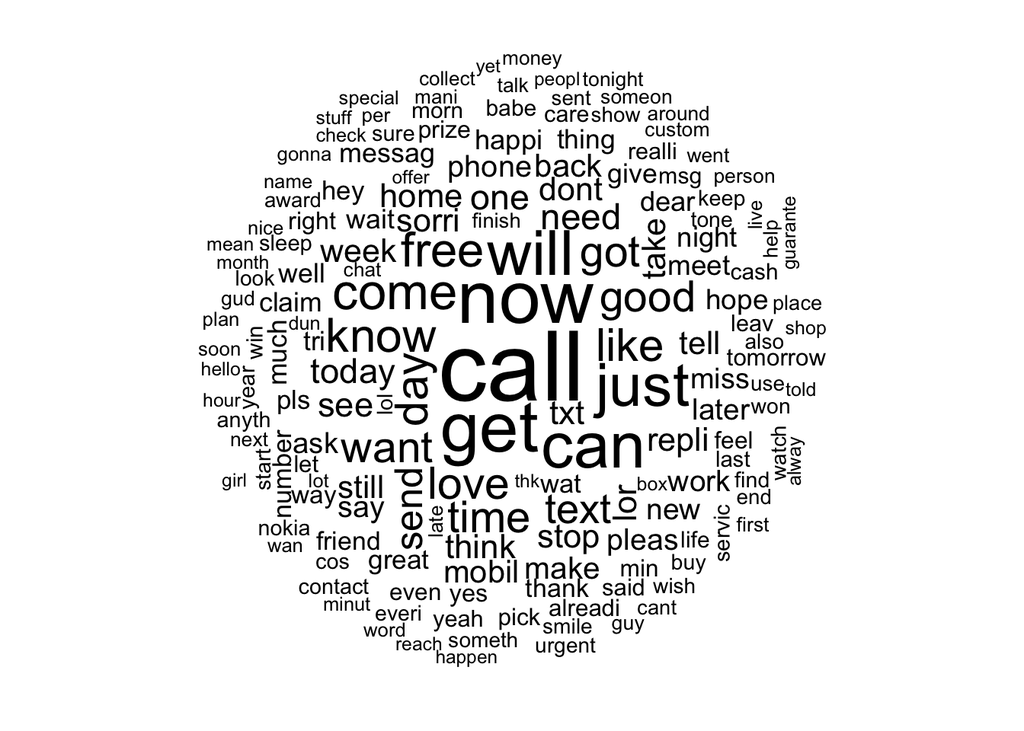

```r
# word cloud visualization
library(wordcloud)
wordcloud(sms_corpus_clean, min.freq = 50, random.order = FALSE)
```

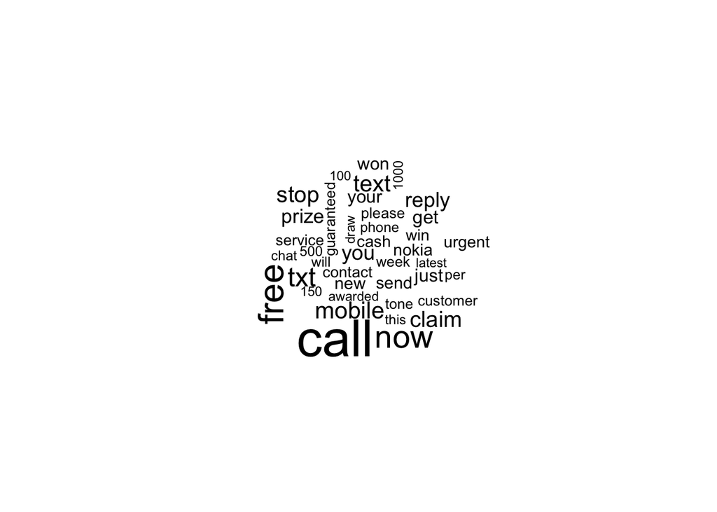

```r
# subset the training data into spam and ham groups
spam <- subset(sms_raw, type == "spam")
ham  <- subset(sms_raw, type == "ham")

wordcloud(spam$text, max.words = 40, scale = c(3, 0.5))
```

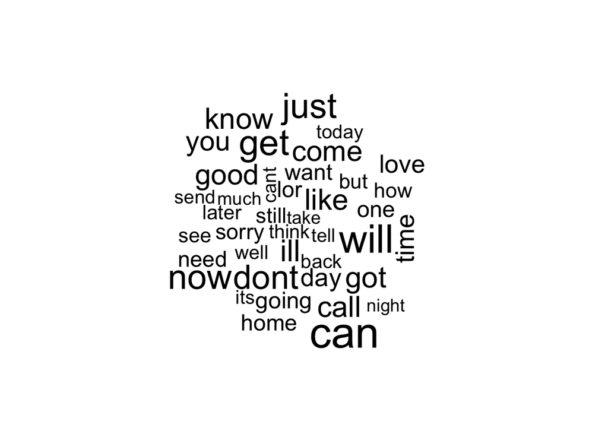

```r
wordcloud(ham$text, max.words = 40, scale = c(3, 0.5))
```

```r
sms_dtm_freq_train <- removeSparseTerms(sms_dtm_train, 0.999)
sms_dtm_freq_train
```

```
## <<DocumentTermMatrix (documents: 4169, terms: 1101)>>
## Non-/sparse entries: 24834/4565235
## Sparsity           : 99%
## Maximal term length: 19
## Weighting          : term frequency (tf)
```

```r
# save frequently-appearing terms to a character vector
sms_freq_words <- findFreqTerms(sms_dtm_train, 5)
str(sms_freq_words)
```

```
##  chr [1:1136] "abiola" "abl" "abt" "accept" "access" ...
```

```r
# create DTMs with only the frequent terms
sms_dtm_freq_train <- sms_dtm_train[ , sms_freq_words]
sms_dtm_freq_test <- sms_dtm_test[ , sms_freq_words]

# convert counts to a factor
convert_counts <- function(x) {
  x <- ifelse(x > 0, "Yes", "No")
}

# apply() convert_counts() to columns of train/test data
sms_train <- apply(sms_dtm_freq_train, MARGIN = 2, convert_counts)
sms_test  <- apply(sms_dtm_freq_test, MARGIN = 2, convert_counts)
```

Before we move along, let’s take a look at what this last step produced:

```r
sms_train[1:5,1:10]
```

```
##     Terms
## Docs abiola abl  abt  accept access account across act  activ actual
##    1 "No"   "No" "No" "No"   "No"   "No"    "No"   "No" "No"  "No"
##    2 "No"   "No" "No" "No"   "No"   "No"    "No"   "No" "No"  "No"
##    3 "No"   "No" "No" "No"   "No"   "No"    "No"   "No" "No"  "No"
##    4 "No"   "No" "No" "No"   "No"   "No"    "No"   "No" "No"  "No"
##    5 "No"   "No" "No" "No"   "No"   "No"    "No"   "No" "No"  "No"
```

So the DTM has been converted into a bunch of columns, one column per word, with an indication as to whether or not that word occurred in each of the messages.

### Part III: Data Modeling

This involves simply applying the naiveBayes function from the e1071 package to our dataset:

```r
sms_classifier <- naiveBayes(sms_train, sms_train_labels)
```

### Part IV: Evaluating Model Performance

We now need to apply the model to the test dataset, and evaluate how accurately the model categorizes messages to be ham or spam.

```r
# run the predictor
sms_test_pred <- predict(sms_classifier, sms_test)
# summarize the results in a table
CrossTable(sms_test_pred, sms_test_labels,
           prop.chisq = FALSE, prop.t = FALSE, prop.r = FALSE,
           dnn = c('predicted', 'actual'))
```

```
##
##
##    Cell Contents
## |-------------------------|
## |                       N |
## |           N / Col Total |
## |-------------------------|
##
##
## Total Observations in Table:  1390
##
##
##              | actual
##    predicted |       ham |      spam | Row Total |
## -------------|-----------|-----------|-----------|
##          ham |      1201 |        30 |      1231 |
##              |     0.995 |     0.164 |           |
## -------------|-----------|-----------|-----------|
##         spam |         6 |       153 |       159 |
##              |     0.005 |     0.836 |           |
## -------------|-----------|-----------|-----------|
## Column Total |      1207 |       183 |      1390 |
##              |     0.868 |     0.132 |           |
## -------------|-----------|-----------|-----------|
##
##
```

The accuracy rate for the model is (1201 + 153) / 1390 = 97.4%, which is really good. However we can always try to do better.

### Part V: Improving Model Performance

Create a better predictor by setting the Laplace estimator to 1 and re-running the algorithm:

```r
sms_classifier2 <- naiveBayes(sms_train, sms_train_labels, laplace = 1)
sms_test_pred2 <- predict(sms_classifier2, sms_test)
CrossTable(sms_test_pred2, sms_test_labels,
           prop.chisq = FALSE, prop.t = FALSE, prop.r = FALSE,
           dnn = c('predicted', 'actual'))
```

```
##
##
##    Cell Contents
## |-------------------------|
## |                       N |
## |           N / Col Total |
## |-------------------------|
##
##
## Total Observations in Table:  1390
##
##
##              | actual
##    predicted |       ham |      spam | Row Total |
## -------------|-----------|-----------|-----------|
##          ham |      1202 |        28 |      1230 |
##              |     0.996 |     0.153 |           |
## -------------|-----------|-----------|-----------|
##         spam |         5 |       155 |       160 |
##              |     0.004 |     0.847 |           |
## -------------|-----------|-----------|-----------|
## Column Total |      1207 |       183 |      1390 |
##              |     0.868 |     0.132 |           |
## -------------|-----------|-----------|-----------|
##
##
```

The accuracy for this rendition of the model is (1202 + 155) / 1390, which is 97.6%. That’s a 0.2% increase in accuracy.

### Comparison of Predictions vs. Actuals

Below, we line up the first 60 sets of the original and improved predictions, alongside the actual “spam” vs “ham” indications:

```r
pred1 <- sms_test_pred[1:60]
pred2 <- sms_test_pred2[1:60]
actuals <- sms_test_labels[1:60]
p1name <- "Original"
p2name <- "Improved"
actname <- "Actual"
df <- data.frame(pred1,pred2,actuals)
df
```

```
##    pred1 pred2 actuals
## 1    ham   ham     ham
## 2    ham   ham     ham
## 3    ham   ham     ham
## 4    ham   ham     ham
## 5   spam  spam    spam
## 6    ham   ham     ham
## 7    ham   ham     ham
## 8    ham   ham     ham
## 9    ham   ham     ham
## 10  spam  spam    spam
## 11   ham   ham     ham
## 12   ham   ham     ham
## 13   ham   ham     ham
## 14  spam  spam    spam
```

[output cut: 46 more lines]

We see that there are differences between the two predictions vs the actuals in rows 53 and 59.